# Robust covariance estimation for partially observed functional data

Hyunsung Kim

2021-05-20

# Completion - Delaigle setting

- Delaigle et al. (2020) setting
- 20% outlier + partially observed
- Fixed hyperparameters (bandwidth, delta in Huber function)
- 50 repetitions
- pre-smoothing X
- PC 개수에 따라 2가지 경우를 고려
  - 5 FPCs
  - PVE = 0.99
- M-est 기반 방법(M-est, Kraus-M 등)에서 noise variance를 가정한 경우도 요약
  - 결과적으로, noise var을 빼주더라도 completion이 더 smooth한 경향은 보이지 않음
    - Yao, Huber는 raw 데이터를 smoothing하지 않는 대신 covariance를 smoothing하여 결과적으로 completion이 smooth한 형태로 나오게 됨
    - 반면, Kraus 방법은 pre-smoothing을 하지 않으면 중간에 smoothing 과정이 없어 다소 wiggly한 형태를 보이게 되는 것으로 보임
- Kraus는 PC score로 completion을 하지 않고, 따로 parameter estimation을 통해 completion 진행
  - 따라서, PC 개수 및 PVE는 정리하지 않음
  - K와 PVE에 depend하지 않기 때문에, Kraus 방법으로 적용한 경우는 두 표의 값이 같음

## 5 FPCs

Table 1. Average MISE, MSE, and its standard errors of completion for simulated data from 50 repetitions.

| Method | Outlier X Noise X (M est) PVE | Outlier X Noise X (M est) MISE | Outlier X Noise X (M est) MSE | Outlier X Noise O (M est) PVE | Outlier X Noise O (M est) MISE | Outlier X Noise O (M est) MSE | Outlier O Noise X (M est) PVE | Outlier O Noise X (M est) MISE | Outlier O Noise X (M est) MSE | Outlier O Noise O (M est) PVE | Outlier O Noise O (M est) MISE | Outlier O Noise O (M est) MSE |
| --- | --- | --- | --- | --- | --- | --- | --- | --- | --- | --- | --- | --- |
| Yao (2005) | 1.00 | 0.53 (1.95) | 2.57 (9.79) |  |  |  | 1.00 | 0.94 (2.42) | 7.67 (19.64) |  |  |  |
| Huber | 0.87 | 0.05 (0.03) | 0.28 (0.16) |  |  |  | 0.87 | 0.06 (0.03) | 0.34 (0.17) |  |  |  |
| M-est | 0.96 | 0.05 (0.04) | 0.24 (0.17) | 0.97 | 0.03 (0.02) | 0.16 (0.09) | 0.72 | 0.15 (0.21) | 0.68 (0.83) | 0.75 | 0.05 (0.03) | 0.26 (0.13) |
| M-est (smooth) | 1.00 | 0.36 (1.31) | 1.35 (4.95) | 1.00 | 0.02 (0.01) | 0.09 (0.05) | 1.00 | 0.04 (0.04) | 0.18 (0.18) | 1.00 | 0.03 (0.02) | 0.15 (0.07) |
| Kraus (2015) |  | 0.03 (0.02) | 0.25 (0.24) |  |  |  |  | 0.37 (0.11) | 2.64 (0.64) |  |  |  |
| Kraus-M |  | 0.06 (0.03) | 0.44 (0.28) |  | 0.06 (0.03) | 0.47 (0.31) |  | 0.16 (0.06) | 1.37 (0.46) |  | 0.19 (0.07) | 1.54 (0.54) |
| Kraus-M (smooth) |  | 0.13 (0.05) | 1.15 (0.42) |  | 0.13 (0.05) | 1.2 (0.47) |  | 0.06 (0.03) | 0.46 (0.34) |  | 0.07 (0.03) | 0.62 (0.36) |

## PVE = 0.99

Table 2. Average MISE, MSE, and its standard errors of completion for simulated data from 50 repetitions.

| Method | Outlier X Noise X (M est) K | Outlier X Noise X (M est) MISE | Outlier X Noise X (M est) MSE | Outlier X Noise O (M est) K | Outlier X Noise O (M est) MISE | Outlier X Noise O (M est) MSE | Outlier O Noise X (M est) K | Outlier O Noise X (M est) MISE | Outlier O Noise X (M est) MSE | Outlier O Noise O (M est) K | Outlier O Noise O (M est) MISE | Outlier O Noise O (M est) MSE |
| --- | --- | --- | --- | --- | --- | --- | --- | --- | --- | --- | --- | --- |
| Yao (2005) | 4.00 | 0.50 (1.91) | 2.45 (9.62) |  |  |  | 3.78 | 0.94 (2.4) | 7.61 (19.42) |  |  |  |
| Huber | 25.32 | 0.05 (0.03) | 0.30 (0.19) |  |  |  | 25.30 | 0.06 (0.03) | 0.37 (0.19) |  |  |  |
| M-est | 12.76 | 0.06 (0.05) | 0.29 (0.19) | 11.84 | 0.03 (0.02) | 0.18 (0.1) | 27.94 | 0.26 (0.26) | 1.12 (1.06) | 22.78 | 0.04 (0.02) | 0.23 (0.11) |
| M-est (smooth) | 4.22 | 0.34 (1.26) | 1.28 (4.66) | 4.22 | 0.02 (0.01) | 0.1 (0.05) | 4.64 | 0.04 (0.04) | 0.17 (0.17) | 4.40 | 0.03 (0.02) | 0.15 (0.07) |
| Kraus (2015) |  | 0.03 (0.02) | 0.25 (0.24) |  |  |  |  | 0.37 (0.11) | 2.64 (0.64) |  |  |  |
| Kraus-M |  | 0.06 (0.03) | 0.44 (0.28) |  | 0.06 (0.03) | 0.47 (0.31) |  | 0.16 (0.06) | 1.37 (0.46) |  | 0.19 (0.07) | 1.54 (0.54) |
| Kraus-M (smooth) |  | 0.13 (0.05) | 1.15 (0.42) |  | 0.13 (0.05) | 1.2 (0.47) |  | 0.06 (0.03) | 0.46 (0.34) |  | 0.07 (0.03) | 0.62 (0.36) |

- PVE = 0.99가 되는 PC 개수가 Huber와 M-est에서 매우 크게 나타남.
  - 다소 높게 잡긴 했지만, 그럼에도 Yao와 M-est(smooth)는 적은 PC 개수로도 0.99를 넘음
  - PVE=0.9까지는 2~3개 정도면 충분하지만, 이후 eigenvalue 값들의 차이가 작아서 PVE 상승폭이 작음

## K=5, Outlier X

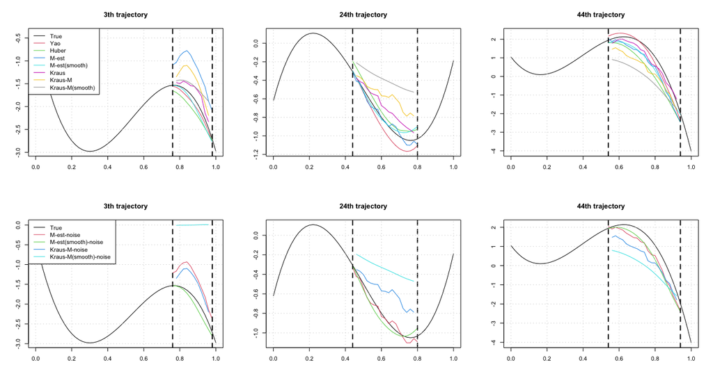

Figure 1. Completion for missing parts of 50th simulated data.

## K=5, Outlier O

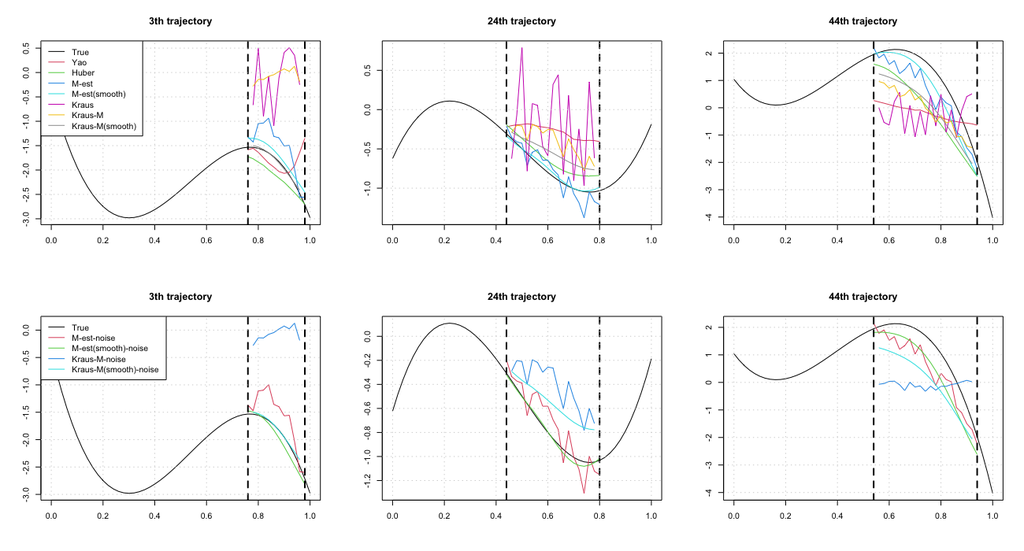

Figure 2. Completion for missing parts of 50th simulated data.

## PVE=0.99, Outlier X

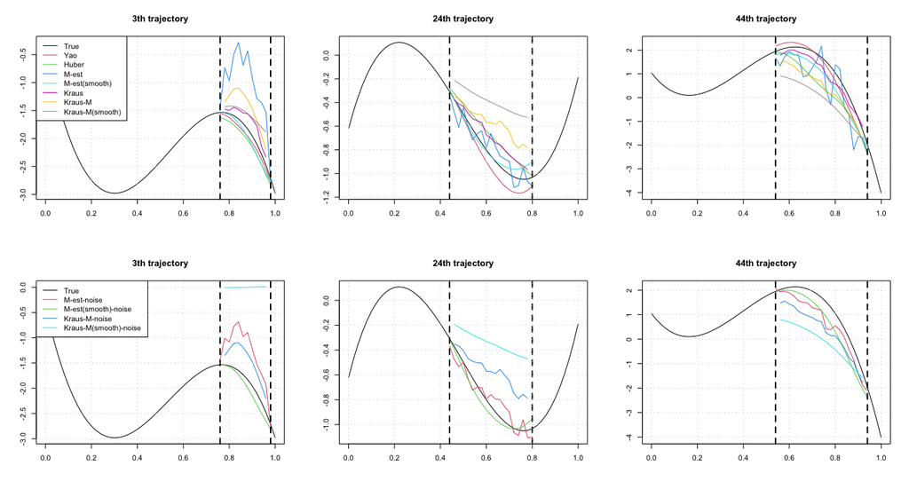

Figure 3. Completion for missing parts of 50th simulated data.

## PVE=0.99, Outlier O

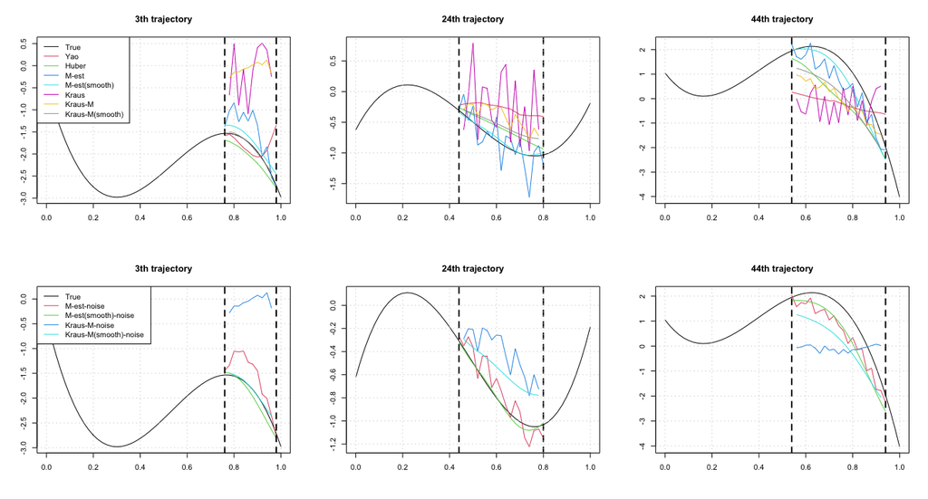

Figure 4. Completion for missing parts of 50th simulated data.

# Completion - shifted Doppler signal

- shifted Doppler signal setting
  - 512 => 128 timepoints로 줄여서 확인
  - Delaigle 세팅과 달리 wiggly한 curve로 이루어짐
- 20% outliers + partially observed
- Fixed hyperparameters (bandwidth, delta in Huber function)
- Huber의 경우, variance가 0이 되는 양끝 부분은 가장 가까운 값으로 대체
- 50 repetitions
- pre-smoothing X
- PC 개수에 따라 2가지 경우를 고려
  - 5 FPCs
  - PVE = 0.99
- Kraus는 PCA 결과를 사용하지 않고, 이와 개별적으로 completion 진행
  - 따라서, PC 개수 및 PVE는 정리하지 않음

## 5 FPCs

Table 3. 100 x average MISE, MSE, and its standard errors of completion for simulated data from 50 repetitions.

| Method | Outlier X Noise X (M est) PVE | Outlier X Noise X (M est) MISE | Outlier X Noise X (M est) MSE | Outlier X Noise O (M est) PVE | Outlier X Noise O (M est) MISE | Outlier X Noise O (M est) MSE | Outlier O Noise X (M est) PVE | Outlier O Noise X (M est) MISE | Outlier O Noise X (M est) MSE | Outlier O Noise O (M est) PVE | Outlier O Noise O (M est) MISE | Outlier O Noise O (M est) MSE |
| --- | --- | --- | --- | --- | --- | --- | --- | --- | --- | --- | --- | --- |
| Yao (2005) | 1.00 | 0.57 (0.06) | 3.24 (0.21) |  |  |  | 1.00 | 11.64 (71.67) | 669.95 (4552.26) |  |  |  |
| Huber | 0.89 | 0.66 (0.07) | 3.68 (0.24) |  |  |  | 0.86 | 0.66 (0.08) | 3.67 (0.28) |  |  |  |
| M-est | 0.75 | 0.23 (0.03) | 1.29 (0.08) | 0.95 | 0.18 (0.02) | 1.13 (0.06) | 0.56 | 0.22 (0.03) | 1.29 (0.09) | 0.71 | 0.19 (0.02) | 1.18 (0.08) |
| M-est (smooth) | 0.99 | 5.84 (6.89) | 22.27 (24.69) | 1.00 | 0.54 (0.06) | 3.07 (0.20) | 0.97 | 11.91 (8.20) | 46.25 (31.31) | 1.00 | 0.54 (0.06) | 3.09 (0.22) |
| Kraus (2015) |  | 0.21 (0.02) | 1.29 (0.09) |  |  |  |  | 3.88 (21.40) | 20.94 (110.73) |  |  |  |
| Kraus-M |  | 0.23 (0.03) | 1.44 (0.11) |  | 0.21 (0.02) | 1.38 (0.13) |  | 0.30 (0.05) | 1.87 (0.18) |  | 0.42 (0.08) | 2.46 (0.35) |
| Kraus-M (smooth) |  | 0.56 (0.06) | 3.18 (0.22) |  | 0.60 (0.06) | 3.41 (0.21) |  | 0.56 (0.07) | 3.25 (0.21) |  | 0.58 (0.07) | 3.35 (0.24) |

## PVE = 0.99

Table 4. 100 x average MISE, MSE, and its standard errors of completion for simulated data from 50 repetitions.

| Method | Outlier X Noise X (M est) K | Outlier X Noise X (M est) MISE | Outlier X Noise X (M est) MSE | Outlier X Noise O (M est) K | Outlier X Noise O (M est) MISE | Outlier X Noise O (M est) MSE | Outlier O Noise X (M est) K | Outlier O Noise X (M est) MISE | Outlier O Noise X (M est) MSE | Outlier O Noise O (M est) K | Outlier O Noise O (M est) MISE | Outlier O Noise O (M est) MSE |
| --- | --- | --- | --- | --- | --- | --- | --- | --- | --- | --- | --- | --- |
| Yao (2005) | 4.00 | 0.57 (0.06) | 3.24 (0.21) |  |  |  | 2.47 | 11.35 (69.68) | 651.55 (4426.26) |  |  |  |
| Huber | 31.88 | 0.67 (0.07) | 3.72 (0.25) |  |  |  | 38.00 | 0.67 (0.08) | 3.70 (0.28) |  |  |  |
| M-est | 66.10 | 1.18 (0.32) | 5.18 (0.97) | 15.14 | 0.19 (0.02) | 1.18 (0.07) | 68.04 | 1.19 (0.37) | 5.26 (1.14) | 25.45 | 0.21 (0.02) | 1.27 (0.09) |
| M-est (smooth) | 5.34 | 6.22 (7.35) | 23.66 (26.36) | 4.00 | 0.54 (0.06) | 3.07 (0.20) | 6.81 | 16.82 (10.62) | 65.90 (40.85) | 4.15 | 0.54 (0.06) | 3.09 (0.22) |
| Kraus (2015) |  | 0.21 (0.02) | 1.29 (0.09) |  |  |  |  | 3.88 (21.40) | 20.94 (110.73) |  |  |  |
| Kraus-M |  | 0.23 (0.03) | 1.44 (0.11) |  | 0.21 (0.02) | 1.38 (0.13) |  | 0.30 (0.05) | 1.87 (0.18) |  | 0.42 (0.08) | 2.46 (0.35) |
| Kraus-M (smooth) |  | 0.56 (0.06) | 3.18 (0.22) |  | 0.60 (0.06) | 3.41 (0.21) |  | 0.56 (0.07) | 3.25 (0.21) |  | 0.58 (0.07) | 3.35 (0.24) |

## K=5, Outlier X

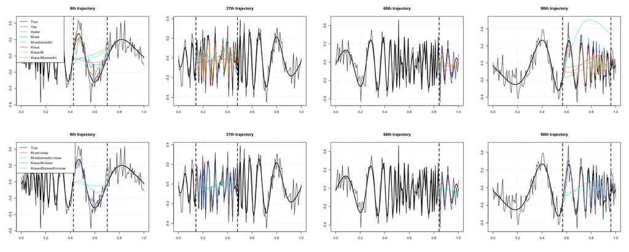

Figure 5. Completion for missing parts of 50th simulated data.

## K=5, Outlier O

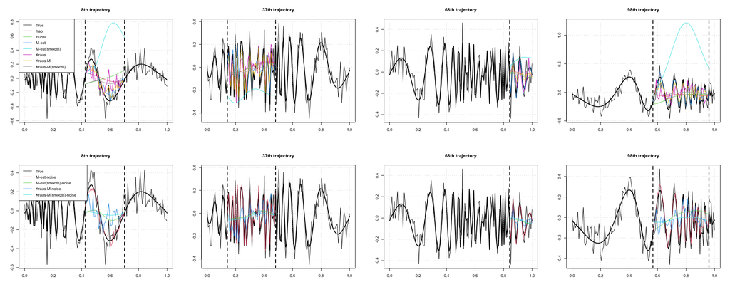

Figure 6. Completion for missing parts of 50th simulated data.

## PVE=0.99, Outlier X

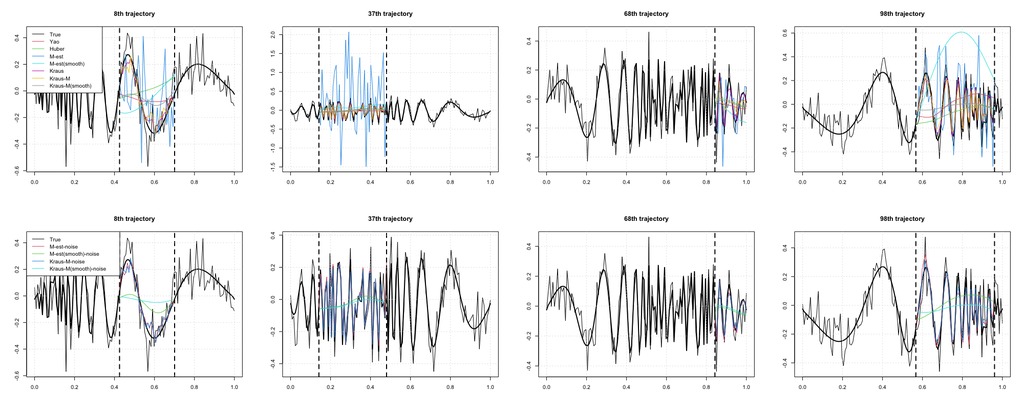

Figure 7. Completion for missing parts of 50th simulated data.

## PVE=0.99, Outlier O

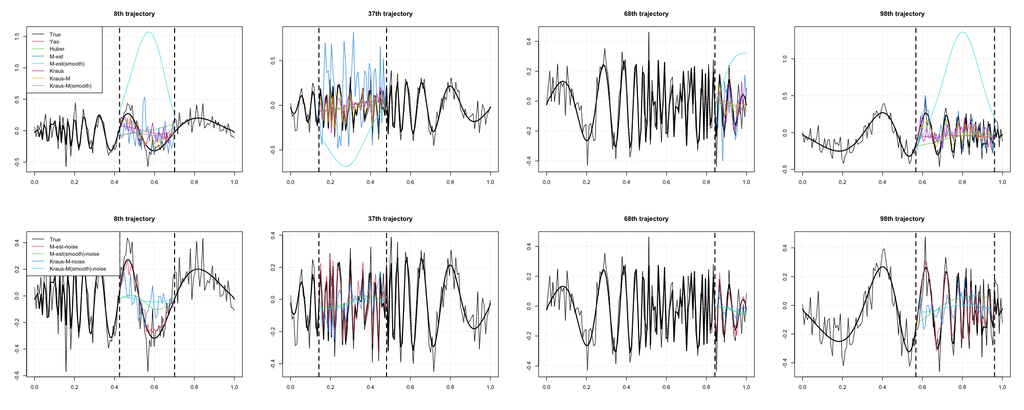

Figure 8. Completion for missing parts of 50th simulated data.